# Price of Flights Prediction Algorithms Based on Alibaba.ir Flights in Azar (Nov-Dec)

## Graph 3 Shows that theyre also the most expensive to travel from

```python
# As Company is Nominal Categorical data we will perform OneHotEncoding
Airline=pd.get_dummies(categorical['Company'],drop_first=True)
```

```python
#encoding of location and Destination columns
source=pd.get_dummies(categorical['Location'],drop_first=True)

destination=pd.get_dummies(categorical['Destination'],drop_first=True)
```

```python
for i in categorical.columns:
    print('{} has total {} categories'.format(i,len(categorical[i].value_counts())))
```

```
Company has total 20 categories
Destination has total 27 categories
Location has total 28 categories
```

```python
df.columns
```

```
Index(['Price', 'Company', 'Destination', 'Location', 'Date', 'jday',
       'Depart_hour', 'Depart_min', 'Arrival_hour', 'Arrival_min', 'Duration'],
      dtype='object')
```

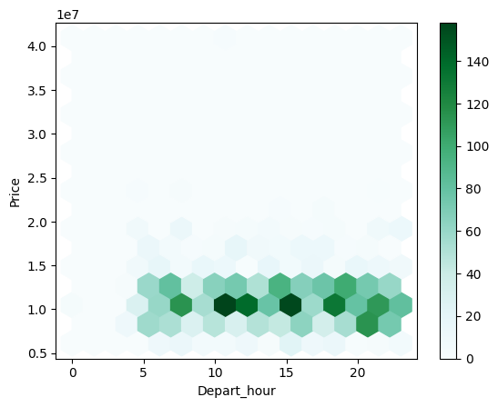

```python
df.plot.hexbin(x='Depart_hour',y='Price',gridsize=15)
```

## Graph 4 Shows Depart hour does not affect price

```python
# Applying label encoder
from sklearn.preprocessing import LabelEncoder
encoder = LabelEncoder()
```

```python
for i in ['Location','Destination','Company']:
    categorical[i]=encoder.fit_transform(categorical[i])
```

```python
categorical.head(70)
```

|  | Company | Destination | Location |
| --- | --- | --- | --- |
| 0 | 17 | 21 | 15 |
| 1 | 3 | 21 | 15 |
| 2 | 3 | 21 | 15 |
| 3 | 7 | 21 | 15 |
| 4 | 17 | 21 | 15 |
| ... | ... | ... | ... |
| 73 | 3 | 14 | 22 |
| 74 | 3 | 14 | 22 |
| 75 | 3 | 14 | 22 |
| 76 | 7 | 14 | 22 |
| 77 | 3 | 14 | 22 |

70 rows × 3 columns

```python
#merge it back in
final_df=pd.concat([categorical,df[continuous_col]],axis=1)
```

```python
pd.set_option('display.max_columns',500)
final_df
```

|  | Company | Destination | Location | Price | Date | jday | Depart_hour | Depart_min | Arrival_hour | Arrival_min | Duration |
| --- | --- | --- | --- | --- | --- | --- | --- | --- | --- | --- | --- |
| 0 | 17 | 21 | 15 | 10500000 | 2022-09-01 | 1 | 16 | 40 | 18 | 10 | 120 |
| 1 | 3 | 21 | 15 | 10700000 | 2022-09-01 | 1 | 20 | 45 | 22 | 25 | 120 |
| 2 | 3 | 21 | 15 | 11000000 | 2022-09-01 | 1 | 20 | 45 | 22 | 25 | 120 |
| 3 | 7 | 21 | 15 | 11000000 | 2022-09-01 | 1 | 16 | 0 | 17 | 45 | 60 |
| 4 | 17 | 21 | 15 | 11000000 | 2022-09-01 | 1 | 16 | 40 | 18 | 10 | 120 |
| ... | ... | ... | ... | ... | ... | ... | ... | ... | ... | ... | ... |
| 3623 | 9 | 23 | 22 | 9289000 | 2022-09-18 | 18 | 11 | 40 | 13 | 10 | 120 |
| 3624 | 11 | 23 | 22 | 9289000 | 2022-09-18 | 18 | 15 | 0 | 16 | 20 | 60 |
| 3625 | 2 | 23 | 22 | 9288000 | 2022-09-18 | 18 | 11 | 35 | 13 | 10 | 120 |
| 3626 | 13 | 23 | 22 | 9289000 | 2022-09-18 | 18 | 9 | 30 | 10 | 50 | 60 |
| 3628 | 19 | 5 | 22 | 6963000 | 2022-09-18 | 18 | 18 | 0 | 19 | 5 | 60 |

3157 rows × 11 columns

```python
#check for outliers
def plot(data,col):
    fig,(ax1,ax2)=plt.subplots(2,1)
    sns.distplot(data[col],ax=ax1)
    sns.boxplot(data[col],ax=ax2)
```

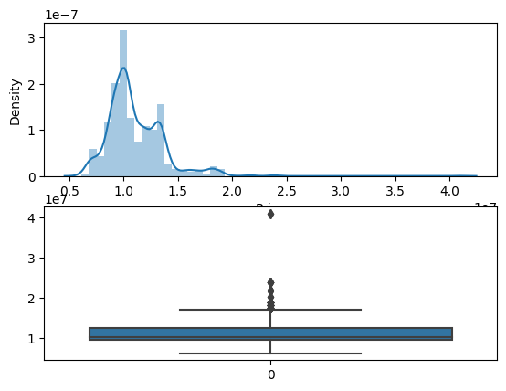

```python
plot(final_df,'Price')
```

## Graph 5 shows us the average price of tickets are around 10million Rials, but range from 5mill to 20mill, we can also see we have one ticket that is at 40million, we can safely consider that an outlier and eliminate it from our dataset

```python
#As there is one outlier in price feature, we will replace it with the median
final_df['Price']=np.where(final_df['Price']>=40000000,final_df['Price'].median(),final_df['Price'])
```

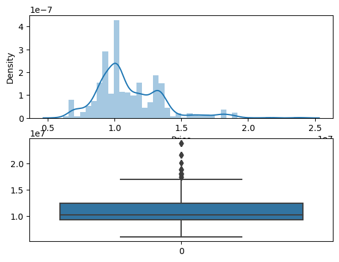

```python
plot(final_df,'Price')
```